# BellaBt Fitness Data Analytics

Makki Buzo

2024-06-16

### Case Study: How Can a Wellness Technology Company Play It Smart?

Scenerio: Bellabeat is a high-tech manufacturer of health-focused products for women.

### Bellabeat’s Objectives:

Bellabeat aims to gain a deeper understanding of user behavior, preferences and identify emerging trends in the smart device market through comprehensive analysis.

1. By Leveraging customer and product data analytics, the marketing team gains insights to inform product enhancements and refine targeted marketing strategies, ultimately improving user satisfaction and driving business growth.
2. This case study would enable Bellabeat to stay at the forefront of the industry and meet evolving consumer needs effectively.

### Stakeholders

Urška Sršen: “Bellabeat’s cofounder and Chief Creative Officer” Sando Mur: “Mathematician and Bellabeat’s cofounder” Bellabeat marketing analytics team: “A team of data analysts responsible for collecting, analyzing, and reporting data that helps guide Bellabeat’s marketing strategy.”

### Problem Statements:

“Bellabeat is a successful small company, but have the potential to become a larger player in the global smart device market. With such an ambitious business goal, The data analytics team has brought forth few explicit questions to answer to achieve the business goal.” 1. What are some trends in smart device usage? 2. How could these trends apply to Bellabeat customers? 3. How could these trends help influence Bellabeat marketing strategy?

### Analysis:

Business Task: Conduct Comprehensive Analysis to Enhance Product Development and Marketing Strategies. This includes examining consumer behavior, trends, and product performance metrics to identify opportunities for optimization and innovation in product offerings and marketing strategies.

### Relevent Information:¶

Data Source: The dataset is sourced from the FitBit Fitness Tracker Data.

License: CC0: Public Domain, dataset made available through Mobius

Data Security: The dataset is stored securely, both on a personal computer and on Kaggle, ensuring the privacy and confidentiality of users’ personal information.

### Dataset Description:

The dataset contains personal fitness tracker data from thirty FitBit users. All thirty users have consented to the submission of their personal tracker data. The data includes minute-level output for physical activity, heart rate, and sleep monitoring. It provides information about daily activity, steps, and heart rate, which can be used to explore users’ habits and behaviors related to health tracking.

### Note: This case study may raise concerns about selection bias because Bellabeat’s smart products are exclusively designed for women.There was no data set that specified expicilty the gender of the users.However, we will assume they are females

### Install the necessary packages

```
install.packges("tidyverse")
install.packages("readr")
install.packages("readxl")
```

### Load the packages library

```
  library(tidyverse)
  library(readr)
  library(readxl)
```

### import the data needed

```
daily_sleep <- read_csv("C:/Users/HP/Downloads/Fitness_Data/Fitabase Data 4.12.16-5.12.16/sleepDay_merged.csv")
daily_activities <- read_csv("C:/Users/HP/Downloads/Fitness_Data/Fitabase Data 4.12.16-5.12.16/dailyActivity_merged.csv")
daily_calories <- read_csv("C:/Users/HP/Downloads/Fitness_Data/Fitabase Data 4.12.16-5.12.16/dailyCalories_merged.csv")
daily_intensities <- read_csv("C:/Users/HP/Downloads/Fitness_Data/Fitabase Data 4.12.16-5.12.16/dailyIntensities_merged.csv")
daily_steps <- read.csv("C:/Users/HP/Downloads/Fitness_Data/Fitabase Data 4.12.16-5.12.16/dailySteps_merged.csv")
heart_rate_in_sec <-  read.csv("C:/Users/HP/Downloads/Fitness_Data/Fitabase Data 4.12.16-5.12.16/heartrate_seconds_merged.csv")
hourly_calories <- read.csv("C:/Users/HP/Downloads/Fitness_Data/Fitabase Data 4.12.16-5.12.16/hourlyCalories_merged.csv")
hourly_intensities <- read.csv("C:/Users/HP/Downloads/Fitness_Data/Fitabase Data 4.12.16-5.12.16/hourlyIntensities_merged.csv")
hourly_steps <- read.csv("C:/Users/HP/Downloads/Fitness_Data/Fitabase Data 4.12.16-5.12.16/hourlySteps_merged.csv")
weight_info_log <- read.csv("C:/Users/HP/Downloads/Fitness_Data/Fitabase Data 4.12.16-5.12.16/weightLogInfo_merged.csv")
weight_info <- read.csv("C:/Users/HP/Downloads/Fitness_Data/Fitabase Data 4.12.16-5.12.16/weight_info.xlsx")
SleepDay <- read_csv("C:/Users/HP/Downloads/Fitness_Data/Fitabase Data 4.12.16-5.12.16/sleepDay_merged.csv")
```

### Check for distinct participants

```
n_distinct(daily_activities$Id)
n_distinct(daily_sleep$Id)
n_distinct(daily_calories$Id)
n_distinct(daily_intensities$Id)
n_distinct(daily_steps$Id)
n_distinct(heart_rate_in_sec$Id)
n_distinct(hourly_calories$Id)
n_distinct(hourly_intensities$Id)
n_distinct(hourly_steps$Id)
n_distinct(weight_info$Id)
n_distinct(weight_info_log$Id)
```

### Check for inconsistencies in data

```
head(daily_activities)
head(hourly_intensities)
head(daily_sleep)
head(daily_calories)
head(daily_steps)
head(hourly_steps)
```

### Convert all the datetime colum to be consistent

### Convert daily_activities to ymd

```
daily_activities$ActivityDate <- as.POSIXct(daily_activities$ActivityDate, format = "%d/%m/%Y")
daily_activities$ActivityDate <- format(daily_activities$ActivityDate, "%Y/%m/%d")
head(daily_activities)
```

```
daily_steps$ActivityDay <- as.POSIXct(daily_steps$ActivityDay, format = "%m/%d/%Y")
daily_steps$ActivityDay <- format(daily_steps$ActivityDay, "%A")
head(daily_steps)
```

### Convert Hourly Steps to Ymd

```
hourly_steps$ActivityHour <- as.POSIXct(hourly_steps$ActivityHour, format = "%m/%d/%Y %I:%M:%S %p")
hourly_steps$ActivityHour <- format(hourly_steps$ActivityHour, "%Y/%m/%d %I:%M:%S %p")
tail(hourly_steps)
```

### Convert Hourly Intensity to ymdI that is year month

```
hourly_intensities$ActivityHour <- as.POSIXct(hourly_intensities$ActivityHour, format = "%d/%m/%Y")
hourly_intensities$ActivityHour <- format(hourly_intensities$ActivityHour, "%Y/%m/%d %I: %M: %S %p")
tail(hourly_intensities)
```

### Convert daily calories to ymd

```
daily_calories$ActivityDay <- as.POSIXct(daily_calories$ActivityDay, format = "%d/%m/%Y")
daily_calories$ActivityDay <- format(daily_calories$ActivityDay, "%Y/%m/%d")
head(daily_calories)
```

```
daily_sleep$SleepDay <- as.POSIXct(daily_sleep$SleepDay, format = "%d/%m/%Y")
daily_sleep$SleepDay <- format(daily_sleep$SleepDay, "%A")
```

# Select the dataframe you need to focus on

```
dailyActivity_clean <- daily_activities%>%
  select(Id,
         TotalSteps,
         TotalDistance,
         Calories,
         ActivityDate,
         VeryActiveDistance,
         VeryActiveMinutes
         )

head(dailyActivity_clean)
```

### Merge the daily_activity_cleaned to daily steps by id to have a comprehensive data

```
mergedActivities <- inner_join(dailyActivity_clean, daily_steps, by = "Id")
```

### Process all activity and prepare it for Analysis

```
AllActivity <- daily_activities %>% group_by(Id) %>%  summarize(
  TotalDistance = sum(TotalDistance),
  SedentaryMinutes = sum(SedentaryMinutes),
  VeryActiveDistance = sum(VeryActiveDistance),
  VeryActiveMinutes=sum(VeryActiveMinutes),
  TotalSteps = sum(TotalSteps),
  TotalCalories = sum(Calories),
)%>% arrange(Id)

head(AllActivity)
```

### Process Sum of Sleeptime and Time Spent in Bed

### Sum and prepare the Total sleeping time

```
summedSleep <- daily_sleep%>%
  group_by(Id)%>%
  summarise(
    TotalSleepRecords =sum(TotalSleepRecords),
    TotalMinutesAsleep= sum(TotalMinutesAsleep),
    TotalTimeInBed= sum(TotalTimeInBed),
  )

head(summedSleep)
```

### Merge sleep and calories burn to understand the relationship between the two

```
sleep_and_calories <- inner_join(summedSleep, daily_calories, by = "Id")
```

### Then Prepare it for analysis and visualization

### Analyze Sleeptime and Energy Spet

```
sleep_and_calories <- sleep_and_calories%>% group_by(Id)%>% summarise(
sumSleepRecord = sum(TotalSleepRecords),
sumTotalMins= sum(TotalMinutesAsleep),
sumTotalTimeInBed = sum(TotalTimeInBed),
sumCalories = sum(Calories)
)

head(sleep_and_calories)
```

### The days users took the most steps

```
most_active_step_days<- daily_steps%>% group_by(ActivityDay)%>%
summarise(steps = sum(StepTotal))%>% arrange(steps)
head(most_active_step_days)
```

### Create a Directory of your desireed location to export the data as csv for visualization

```
VeryActiveDay <- "C:\\Users\\HP\\Desktop\\R studio Projects\\BellaBeat Fitness Analytics\\AllActivity.csv"
SummedSleep <- "C:\\Users\\HP\\Desktop\\R studio Projects\\BellaBeat Fitness Analytics\\SummedSleep.csv"
SleepAndCalories <- "C:\\Users\\HP\\Desktop\\R studio Projects\\BellaBeat Fitness Analytics\\sleep_and_calories.csv"
MostActiveStepDays <- "C:\\Users\\HP\\Desktop\\R studio Projects\\BellaBeat Fitness Analytics\\MostAciveStepsDays.csv"
```

### Export the data frame to CSV To Be visualized with Excel

```
write.csv(AllActivity, file = VeryActiveDay, row.names = FALSE)
write.csv(summedSleep, file = SummedSleep, row.names = FALSE)
write.csv(sleep_and_calories, file = SleepAndCalories, row.names = FALSE)
write.csv(most_active_step_days, file = MostActiveStepDays, row.names = FALSE)
```

### View the File

```
View(VeryActiveDay)
```

### Create a Visualizatio of the data in excel

View(MostActiveStepDays)

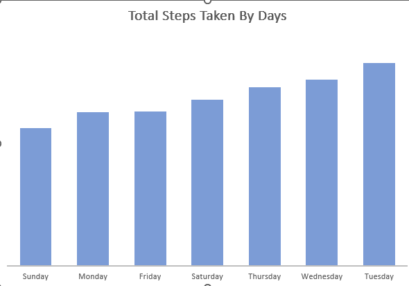

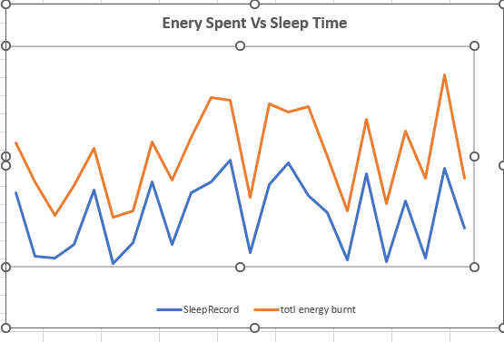

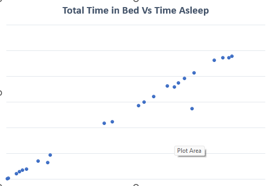